# Space Syntax analysis in R

3. Space Syntax Analysis

Petros Koutsolampros

Kimon Krenz

This document is the third part of a workshop that presents a workflow for working with spatial data common to the space syntax field in the R programming language. Find all parts here: 1. Basic functionality of R 2. Spatial data and its forms 3. Space Syntax Analysis using the alcyon package 4. Advanced: Graphs and J-Graphs 5. Advanced: Isovist networks

## Space Syntax Analysis using the alcyon package

The alcyon package was created in order to make the functionality of depthmapX available in R. It is a wrapper around the sala and generics libraries which encapsulate the core space syntax functionality without a Graphical User Interface. All functions called here are available in the Help section or by calling the function with a question mark in front. They can be called either with the prefix alcyon:: or just plain. Here, to make explicit which functions are part of the package they will be called with the prefix.

### Axial analysis

A typical workflow when using depthmapX is to load line data, convert those lines to an axial map and then do axial analysis.

Let’s load line data into R:

```r
barnsburySmall = st_read("data/barnsbury/barnsbury_small_axial.mif",
                         geometry_column = 1L, quiet = TRUE)
```

Then convert the map to an Axial ShapeGraph and carry out axial analysis for two radii, “n” and 3. We will also include choice.

```r
barnsburySmallAxial = as(barnsburySmall, "AxialShapeGraph")
alcyon::allToAllTraverse(barnsburySmallAxial,
                         radii = c("n", "3"),
                         traversalType = TraversalType$Angular,
                         includeBetweenness = TRUE)
```

```
Simple feature collection with 61 features and 37 fields
Geometry type: LINESTRING
Dimension:     XY
Bounding box:  xmin: 530635.7 ymin: 183499.9 xmax: 531446.8 ymax: 184584
CRS:           NA
First 10 features:
   Depthmap_Ref Choice Choice_Line_Length_Wgt_ Choice_Line_Length_Wgt_Norm_
1             0    182                17580946                   0.18480287
2             1    360                25343200                   0.26639614
3             2    151                 5913097                   0.06215577
4             3    123                10576759                   0.11117806
5             4     10                 1522734                   0.01600628
6             5     10                 1555573                   0.01635148
7             6     66                 3922796                   0.04123464
8             7    447                23175612                   0.24361144
```

[output cut: 90 more lines]

```r
barnsburyAxialAnalysed = as(barnsburySmallAxial, "sf")
```

Finally, let’s take a look at the column names of our new sf lines data.frame

```r
names(barnsburyAxialAnalysed)
```

```
 [1] "Depthmap_Ref"                 "Choice"
 [3] "Choice_Line_Length_Wgt_"      "Choice_Line_Length_Wgt_Norm_"
 [5] "Choice_Norm_"                 "Connectivity"
 [7] "Integration_HH_"              "Line_Length"
 [9] "Mean_Depth"                   "Mean_Depth_Line_Length_Wgt_"
[11] "Node_Count"                   "RA"
[13] "Total_Depth"                  "Total_Line_Length"
[15] "geometry"                     "Data Map Ref"
[17] "Line Length"
```

Let’s plot the newly analysed map, this time using one of depthmap’s palettes, provided by the package (Axmanesque is the default palette in depthmapX). We will also make the background of the map black using par(bg = “black”).

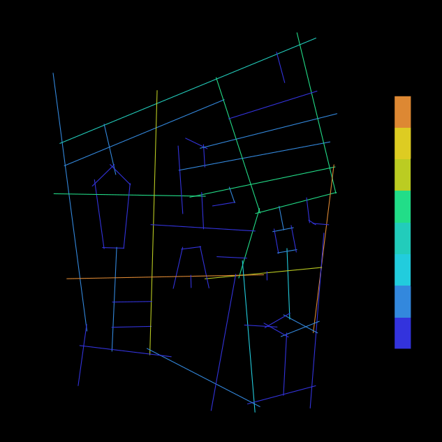

```r
par(bg = "black")
plot(barnsburyAxialAnalysed[,'Choice'], pal = alcyon::depthmap.axmanesque.colour)
```

### alcyon: Segment analysis

To carry out segment analysis, here we first convert the axial map to a segment map and then do segment analysis using three radii, “n”, 50 and 100. The radius type used is “metric”. As previously names() will give us the columns of our new sf data.frame.

```r
barnsburySmallAxial = as(barnsburySmall, "AxialShapeGraph")
barnsburySmallSegment = alcyon::axialToSegmentShapeGraph(barnsburySmallAxial,
                                                         stubRemoval = 0.4)
segmentAnalysed = alcyon::allToAllTraverse(
  barnsburySmallSegment,
  traversalType = TraversalType$Angular,
  quantizationWidth = pi/1024,
  radii = c("n", "50", "100"),
  radiusTraversalType = TraversalType$Metric,
  includeBetweenness = TRUE,
  weightByAttribute = "Segment Length")

names(segmentAnalysed)
```

```
 [1] "Angular Connectivity"
 [2] "Axial Connectivity"
 [3] "Axial Data Map Ref"
 [4] "Axial Line Length"
 [5] "Axial Line Ref"
 [6] "Axial df_10_Mean_Depth_Line_Length_Wgt_"
 [7] "Axial df_11_Node_Count"
 [8] "Axial df_12_RA"
 [9] "Axial df_13_Total_Depth"
[10] "Axial df_14_Total_Line_Length"
[11] "Axial df_1_Depthmap_Ref"
[12] "Axial df_2_Choice"
[13] "Axial df_3_Choice_Line_Length_Wgt_"
[14] "Axial df_4_Choice_Line_Length_Wgt_Norm_"
[15] "Axial df_5_Choice_Norm_"
```

[output cut: 33 more lines]

Let’s then plot the segment map, using depthmapX “classic” palette:

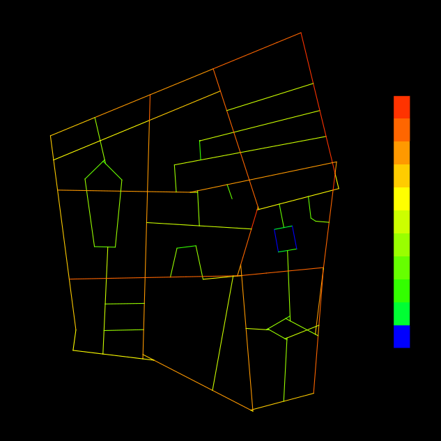

```r
par(bg = "black")
plot(segmentAnalysed[,'T1024 Integration [Segment Length Wgt]'],
     pal = alcyon::depthmap.classic.colour)
```

Another typical step of the workflow is to identify the “Integration core”. That is a subset of the lines the integration of which is above 90% of the overall integration of all lines. The alcyon package provides the function alcyon::getTopFeatures() for exactly this purpose, which will return the subset as an sf lines data.frame Here, the integration core is plotted in thicker lines above the barnsbury segment model

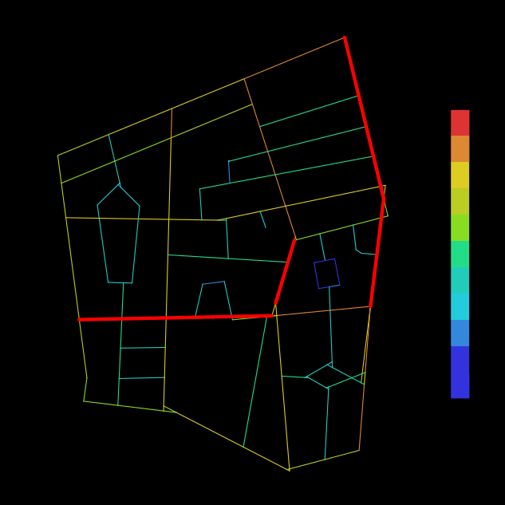

```r
integrationCore = alcyon::getTopFeatures(segmentAnalysed,
                                         "T1024 Integration [Segment Length Wgt]",
                                         percent = 0.1)
cols = (100)
par(bg = "black")
plot(segmentAnalysed[, "T1024 Integration [Segment Length Wgt]"],
     pal = alcyon::depthmap.axmanesque.colour,
     main = "Segment map with Integration core",
     reset = FALSE)
plot(integrationCore[,1], add = TRUE, col = "red", lwd = 4)
```

### alcyon: Visibility Graph Analysis

Finally, we may perform VGA directly from R, by loading a floorplan, defining and filling a grid and carrying out the analysis.

The next chunk loads and plots a simplified National Gallery plan provided here as a pair of MIF/MID files. For more advanced floor-plan loading with more elements, look at the package dxfspatial

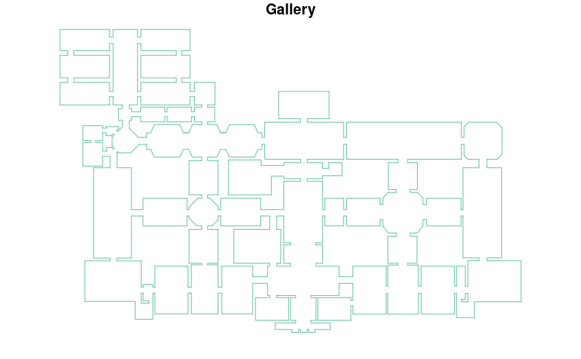

```r
galleryLines = st_read("data/gallery/gallery_lines.mid",
                       geometry_column = 1L,
                       quiet = TRUE)
plot(galleryLines[,1], key.pos = NULL, main = "Gallery")
```

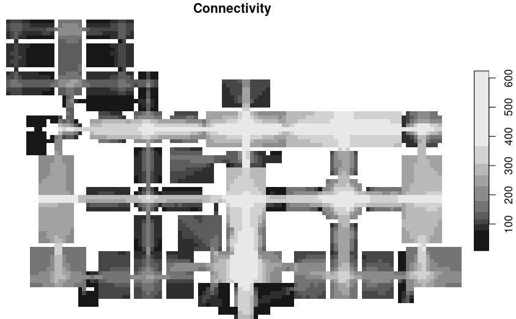

```r
galleryVGA = alcyon::makeVGAPointMap(galleryLines,
                                     gridSize = 0.04,
                                     fillX = 2.86,
                                     fillY = 6.68)
plot(galleryVGA["Connectivity"])
```

We may also link coordinates (if for example we have different floors):

```r
galleryVGA = alcyon::linkCoords(galleryVGA,
                                fromX = 4.81, fromY = 6.67,
                                toX = 2.39, toY = 5.23)
```

And then carry out VGA. The next chunk carries out two modes of VGA, “global-visibility” which calculates metrics such as Visual Mean Depth, Integration and “isovist”, which calculates metrics such as Isovist Area, Isovist Min Radial etc. See ?alcyon::allToAllTraverse for more.

```r
galleryVGA = alcyon::allToAllTraverse(galleryVGA,
                                      radii = c(-1),
                                      traversalType = TraversalType$Topological)
galleryVGA = alcyon::vgaIsovist(galleryVGA,
                                boundaryMap = as(galleryLines[, c()],
                                                 "ShapeMap"))

names(galleryVGA)
```

```
 [1] "Ref"                          "Connectivity"
 [3] "Point First Moment"           "Point Second Moment"
 [5] "blocked"                      "contextfilled"
 [7] "filled"                       "Visual Entropy"
 [9] "Visual Integration [HH]"      "Visual Integration [P-value]"
[11] "Visual Integration [Tekl]"    "Visual Mean Depth"
[13] "Visual Node Count"            "Visual Relativised Entropy"
[15] "Isovist Area"                 "Isovist Compactness"
[17] "Isovist Drift Angle"          "Isovist Drift Magnitude"
[19] "Isovist Max Radial"           "Isovist Min Radial"
[21] "Isovist Occlusivity"          "Isovist Perimeter"
```

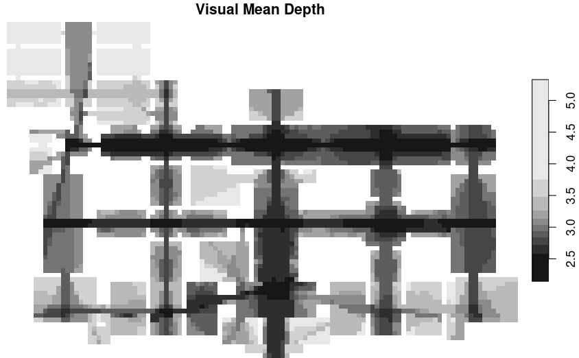

```r
plot(galleryVGA["Visual Mean Depth"])
```

We may also carry out Agent analysis after we have the grid using the command alcyon::agentAnalysis():

```r
galleryAgents = alcyon::agentAnalysis(galleryVGA,
                                      agentLookMode = AgentLookMode$Standard,
                                      timesteps = 5000,
                                      releaseRate = 0.1,
                                      agentFov = 16,
                                      agentSteps = 3,
                                      agentLife = 500,
                                      numberOfTrails = 50)
names(galleryAgents$pointMap)
```

```
 [1] "Ref"                          "Connectivity"
 [3] "Point First Moment"           "Point Second Moment"
 [5] "blocked"                      "contextfilled"
 [7] "filled"                       "Visual Entropy"
 [9] "Visual Integration [HH]"      "Visual Integration [P-value]"
[11] "Visual Integration [Tekl]"    "Visual Mean Depth"
[13] "Visual Node Count"            "Visual Relativised Entropy"
[15] "Isovist Area"                 "Isovist Compactness"
[17] "Isovist Drift Angle"          "Isovist Drift Magnitude"
[19] "Isovist Max Radial"           "Isovist Min Radial"
[21] "Isovist Occlusivity"          "Isovist Perimeter"
[23] "Gate Counts"
```

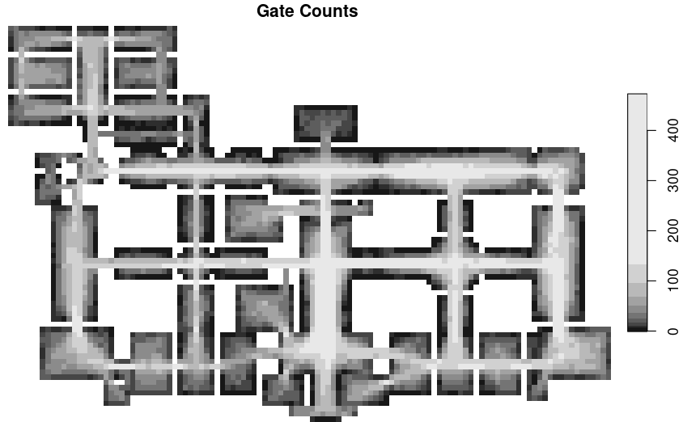

```r
plot(galleryAgents$pointMap["Gate Counts"])
```

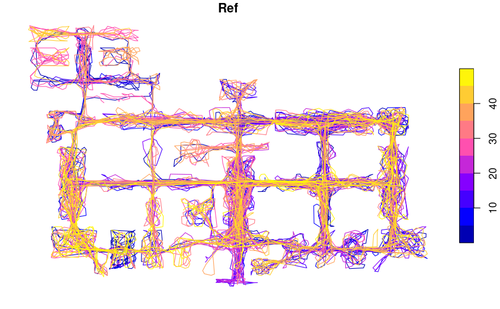

```r
plot(galleryAgents$trailMap)
```

## Statistics

### Simple aggregates

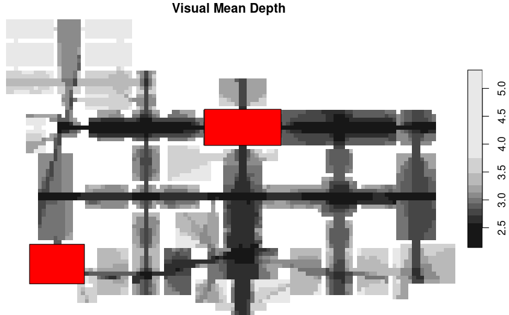

```r
galleryFunction = st_read("data/gallery/gallery_polys.mid", geometry_column = 1L, quiet = TRUE)
plot(galleryVGA["Visual Mean Depth"], reset = FALSE)
plot(galleryFunction[,1], add = TRUE, col = "red")
```

```r
galleryVGAPoints = sf::st_as_sf(galleryVGA, as_points = TRUE)
galleryVGAPoints = galleryVGAPoints[!is.nan(galleryVGAPoints[["Visual Integration [HH]"]]), ]
overlapsDF = st_within(galleryVGAPoints, galleryFunction, sparse = F)
overlapsDF = apply(overlapsDF, 1, function(row) { ifelse(any(row), which(row), NA)})
aggregate(galleryVGAPoints["Visual Integration [HH]"], by = list(overlapsDF), mean)
```

```
Simple feature collection with 2 features and 2 fields
Attribute-geometry relationships: aggregate (1), identity (1)
Geometry type: MULTIPOINT
Dimension:     XY
Bounding box:  xmin: 0.92 ymin: 5.12 xmax: 3.44 ymax: 6.84
CRS:           NA
  Group.1 Visual Integration [HH]                       geometry
1       1                5.506449 MULTIPOINT ((2.68 6.6), (2....
2       2                3.696960 MULTIPOINT ((0.92 5.12), (0...
```

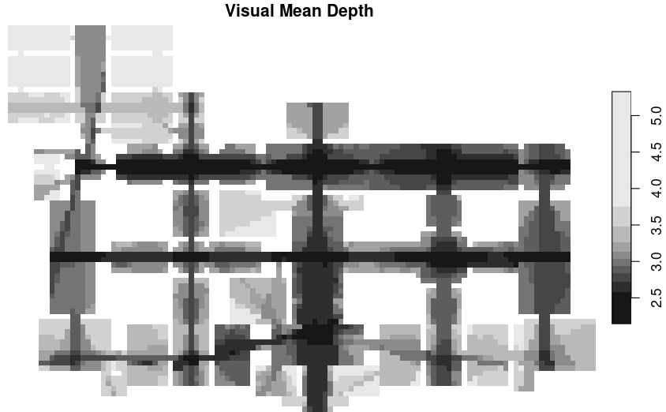

```r
gallerySnapshot = st_read("data/gallery/gallery_snapshot.mid", geometry_column = 1L, quiet = TRUE)
plot(galleryVGA["Visual Mean Depth"])
plot(gallerySnapshot, add = TRUE, pch = 20, col = "white")
```

And then let’s find the number of people in each gally per activity:

```r
overlapsDF = st_within(sf::st_as_sf(gallerySnapshot), galleryFunction, sparse = F)
overlapsDF = apply(overlapsDF, 1, function(row) { ifelse(any(row), which(row), NA)})
aggregate(gallerySnapshot$activity, by = list(overlapsDF, gallerySnapshot$activity), length)
```

| Group.1 | Group.2 | x |
| --- | --- | --- |
| 1 | standing | 5 |

### Simple correlation

To carry out simple correlation we’ll first load the large barnsbury axial map, convert it to a segment map and compare it to gatecounts:

First the segment map:

```r
barnsburyLarge = st_read("data/barnsbury/barnsbury_axial.mid",
                         geometry_column = 1L, quiet = TRUE)

barnsburyLargeAxial = as(barnsburyLarge, "AxialShapeGraph")

barnsburyLargeSegment = alcyon::axialToSegmentShapeGraph(barnsburyLargeAxial,
                                                         stubRemoval = 0.4)
segmentAnalysed = alcyon::allToAllTraverse(
  barnsburyLargeSegment,
  traversalType = TraversalType$Angular,
  quantizationWidth = pi/1024,
  radii = c("n", "50", "100"),
  radiusTraversalType = TraversalType$Metric,
  includeBetweenness = TRUE,
  weightByAttribute = "Segment Length")
```

```r
gateCounts = st_read("data/barnsbury/barnsbury_ped_gatecounts.mid",
                     geometry_column = 1L, quiet = TRUE)
```

Plot the segment map with the gatecounts loaded earlier

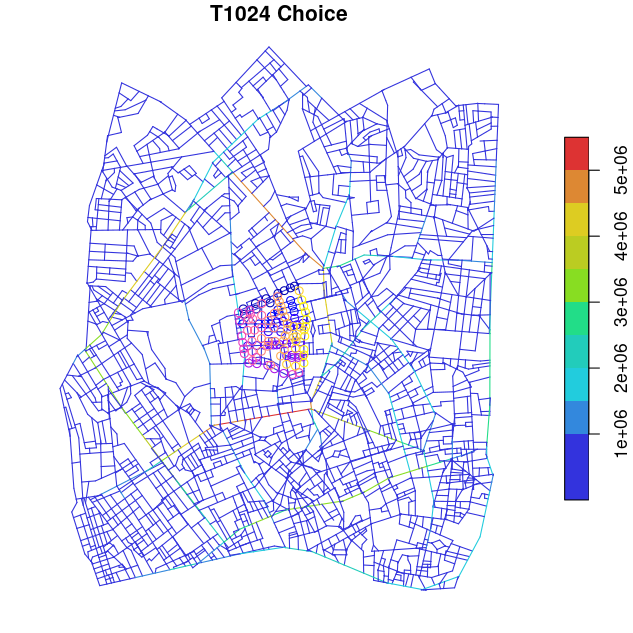

```r
plot(segmentAnalysed[, 'T1024 Choice'], pal = depthmap.axmanesque.colour, reset = F)
plot(gateCounts[,1], add = TRUE)
```

Then match the gatecount points to a line. Each point is assigned here to a single line and vice versa using the command alcyon::matchPointsToLines(). The gatecount data are then transferred as a column back into the sf lines data.frame using cbind()

```r
matchedLines = alcyon::matchPointsToLines(gateCounts, segmentAnalysed)
segmentAnalysed = cbind(segmentAnalysed, matchedLines)
```

A simple linear model can then be carried out using lm() to create the model and summary() to see the statistics:

```r
frm = as.formula("mov_ped_ph ~ T1024.Choice")
mod = lm(frm, segmentAnalysed)
summary(mod)
```

```
Call:
lm(formula = frm, data = segmentAnalysed)

Residuals:
     Min       1Q   Median       3Q      Max
-107.952  -22.318   -7.452   21.290  121.925

Coefficients:
              Estimate Std. Error t value Pr(>|t|)
(Intercept)  4.605e+01  4.369e+00   10.54   <2e-16 ***
T1024.Choice 1.684e-04  8.851e-06   19.03   <2e-16 ***
---
Signif. codes:  0 ‘***’ 0.001 ‘**’ 0.01 ‘*’ 0.05 ‘.’ 0.1 ‘ ’ 1

Residual standard error: 37.97 on 107 degrees of freedom
  (6962 observations deleted due to missingness)
Multiple R-squared:  0.7719,    Adjusted R-squared:  0.7698
F-statistic: 362.1 on 1 and 107 DF,  p-value: < 2.2e-16
```

We may also plot the data in a scatterplot and add a regression line:

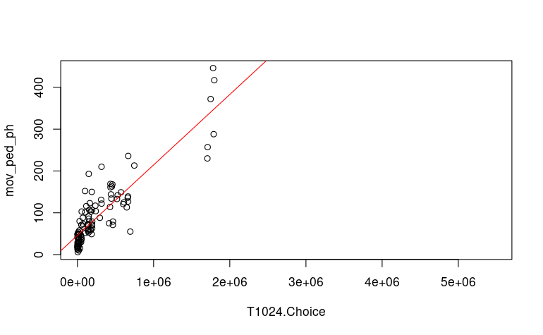

```r
plot(frm, data = segmentAnalysed)
abline(mod, col = "red")
```

To see residuals and other statistics the model may also be inserted into the plot() function

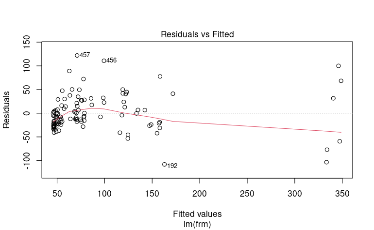

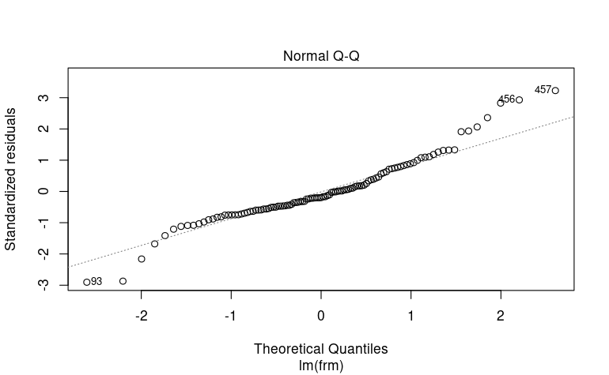

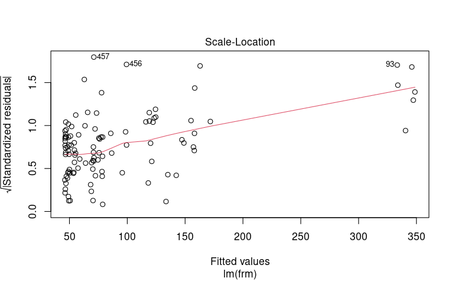

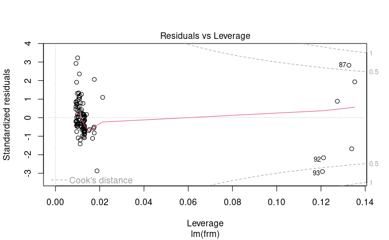

```r
plot(mod)
```

```r
frm = as.formula("mov_ped_ph ~ T1024.Choice + T1024.Integration")
mod = lm(frm, segmentAnalysed)
summary(mod)
```

```
Call:
lm(formula = frm, data = segmentAnalysed)

Residuals:
     Min       1Q   Median       3Q      Max
-116.626  -18.010   -4.744   17.740  118.848

Coefficients:
                    Estimate Std. Error t value Pr(>|t|)
(Intercept)       -4.544e+01  4.424e+01  -1.027   0.3067
T1024.Choice       1.477e-04  1.325e-05  11.145   <2e-16 ***
T1024.Integration  5.447e-02  2.621e-02   2.078   0.0401 *
---
Signif. codes:  0 ‘***’ 0.001 ‘**’ 0.01 ‘*’ 0.05 ‘.’ 0.1 ‘ ’ 1

Residual standard error: 37.4 on 106 degrees of freedom
  (6962 observations deleted due to missingness)
Multiple R-squared:  0.7808,    Adjusted R-squared:  0.7767
F-statistic: 188.8 on 2 and 106 DF,  p-value: < 2.2e-16
```